# Overview

Yan Zhu

2025-01-04

# Part 1: Reading Comprehension Questions (10 pts)

## 1.

- Hypothesis 1: A researcher hypothesizes that the severity of ADHD symptoms (*adhd*) will predict performance on a basic cognitive task (*perf*).
- Hypothesis 2: The researcher further hypothesizes that the relationship between ADHD severity and performance will be moderated by condition (*condition*), an experimentally manipulated predictor, in which participants are assigned to either view (or to not view) brightly colored, animated icons on the screen of the computer being used for the task.
- Control Variable: When testing these two hypotheses she decides to control for processing speed (*speed*).

### a. Write out the correct (augmented) model that would allow the researcher to test both of the hypotheses and control for processing speed. When writing your model, use the italicized variable names provided in parentheses. (2)

perf = b0 + b1 * *adhd_c* + b2 * *condition_c* + b3 * *adhd_c* * *condition_c* + b4 * *speed_c* + b5 * *speed_c* * *condition_c*

### b. Write the compact model for question 1a which tests whether the main effect of ADHD symptom severity is significant. (1)

perf = b0 + b2 * *condition_c* + b3 * *adhd_c* * *condition_c* + b4 * *speed_c* + b5 * *speed_c* * *condition_c*

### c. Write the compact model for question 1a which tests whether the interaction between ADHD symptom severity and condition is significant. (1)

perf = b0 + b1 * *adhd_c* + b2 * *condition_c* + b4 * *speed_c* + b5 * *speed_c* * *condition_c*

## 2. According to Judd et al., 2014, what complicates the testing of interactions with measured predictors, specifically with regard to obtaining adequate statistical power? (2)

Unreliability of the measured variables is multiplied in a product term involving those variables, thus decreasing the reliability of the product term substantially. With decreased reliability the power to detect an effect, given some true effect size, decreases drastically. Restrition of range in the measured variables results in a multiplicative reduction of variance in the product of those variables, decreasing the extremeness of the possible values and thus requiring higher power to detect an effect.

## 3. Explain the additive assumption described by Judd et al., 2017. What does the “reasonableness” of this assumption depend on? (2)

The additive assumption asserts that regardless of the level of X1 , the relationship (i.e., slope) between Y and X2 does not change. Likewise, regardless of the level of X2, the relationship between Y and X1 is presumed not to change. We can simply “add” up the “effects” of two predictors in deriving Y. The reasonableness of the assumption depends on the substantive domain under examination (i.e., whether the effects of the predictors X1 and X2 on Y truly can be assumed to not affect each other, meaning they do not interact with one another).

# Study 1

## 1. Import and examine your data file (“med_school.csv”). Include 1 to 2 sentences noting strong/weak relationships between predictors and any odd or unusual stats or distributions.

```r
d <- read.csv("/Users/yanzhu/Desktop/sample_code/Design and Analysis of Psychological Experiments/Data/med_school.csv") %>% janitor::clean_names()

describe(d)
```

```
##            vars   n  mean    sd median trimmed   mad min   max range  skew
## id            1 150 75.50 43.45   75.5   75.50 55.60   1 150.0 149.0  0.00
## time          2 150 10.74  5.84   12.0   10.90  7.41   1  20.0  19.0 -0.19
## workshop      3 150  0.52  0.50    1.0    0.53  0.00   0   1.0   1.0 -0.08
## confidence    4 150  3.73  1.90    3.9    3.70  1.93   0   9.7   9.7  0.16
##            kurtosis   se
## id            -1.22 3.55
## time          -1.28 0.48
## workshop      -2.01 0.04
## confidence    -0.30 0.16
```

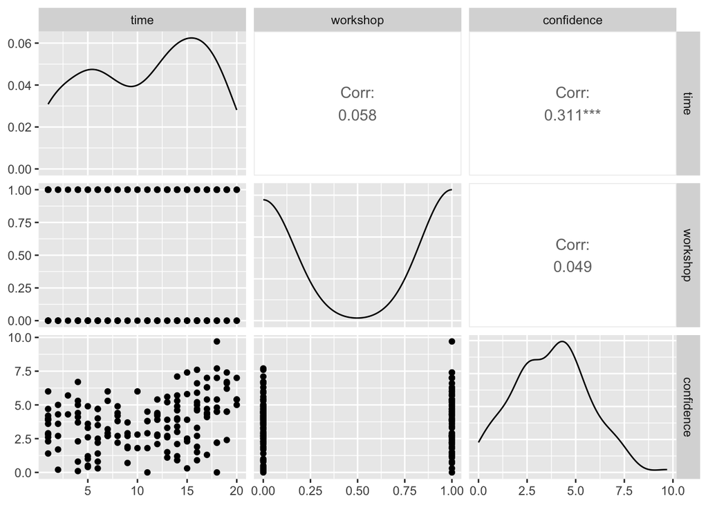

```r
GGally::ggpairs(d[,2:4])
```

All values appear within the expected range for these variables, so I am not removing anything. I note that there is a positive correlation between time and confidence, which might not be linear.

## 2. Fit an additive linear regression model predicting confidence from time, including workshop as a covariate. Interpret the model fully, including the b’s, F values, p values, and np2. (3)

```r
m_linear <- lm(confidence ~ time + workshop, data = d)
summary(m_linear)
```

```
##
## Call:
## lm(formula = confidence ~ time + workshop, data = d)
##
## Residuals:
##     Min      1Q  Median      3Q     Max
## -4.5174 -1.2735  0.1023  1.3486  5.1826
##
## Coefficients:
##             Estimate Std. Error t value Pr(>|t|)
## (Intercept)  2.58289    0.34157   7.562 3.97e-12 ***
## time         0.10084    0.02558   3.942 0.000125 ***
## workshop     0.11930    0.29803   0.400 0.689512
## ---
## Signif. codes:  0 '***' 0.001 '**' 0.01 '*' 0.05 '.' 0.1 ' ' 1
##
## Residual standard error: 1.821 on 147 degrees of freedom
## Multiple R-squared:  0.0978, Adjusted R-squared:  0.08552
## F-statistic: 7.967 on 2 and 147 DF,  p-value: 0.0005186
```

```r
car::Anova(m_linear, type = 3)
```

```
## Anova Table (Type III tests)
##
## Response: confidence
##             Sum Sq  Df F value    Pr(>F)
## (Intercept) 189.51   1 57.1814 3.966e-12 ***
## time         51.50   1 15.5381 0.0001247 ***
## workshop      0.53   1  0.1602 0.6895119
## Residuals   487.19 147
## ---
## Signif. codes:  0 '***' 0.001 '**' 0.01 '*' 0.05 '.' 0.1 ' ' 1
```

```r
car::Anova(m_linear, type = 3) %>% eta_squared()
```

```
## # Effect Size for ANOVA (Type III)
##
## Parameter | Eta2 (partial) |       95% CI
## -----------------------------------------
## time      |           0.10 | [0.03, 1.00]
## workshop  |       1.09e-03 | [0.00, 1.00]
##
## - One-sided CIs: upper bound fixed at [1.00].
```

- $b_0$ = 2.58. Participants who did not participate in the workshop and have spent 0 quarters in medical school have a confidence score of 2.58.
- $b_1$ = 0.10. For every additional academic quarter a student spends in medical school, their confidence increases by 0.10 units, when controlling for the effects of attending the confidence-boosting workshop, $b_1 = .10, F(1, 147) = 15.54, p < .001, np2 = 0.10$.
- $b_2$ = 0.12. Students who attended the workshop have a predicted increase in confidence of 0.12 units compared to those who did not attend the workshop, when controlling for the effect of time. However, this effect was not significant, $b_2 = 0.12, F(1, 147) = 0.16, p = .69, n_p^2 = 0.00$.

## 3. Fit a regression model to test for the quadratic effect of time, statistically controlling for whether students completed the workshop. Interpret the quadratic effect fully, including the b’s, F values, p values, and np2. (3)

```r
d$time_c <- d$time - mean(d$time, na.rm = T)
```

```r
m_quad <- lm(confidence ~ time_c + I(time_c^2) + workshop, data = d)
summary(m_quad)
```

```
##
## Call:
## lm(formula = confidence ~ time_c + I(time_c^2) + workshop, data = d)
##
## Residuals:
##     Min      1Q  Median      3Q     Max
## -4.9383 -1.1000 -0.0097  1.2396  4.7617
##
## Coefficients:
##             Estimate Std. Error t value Pr(>|t|)
## (Intercept) 3.136666   0.263303  11.913  < 2e-16 ***
## time_c      0.119959   0.025453   4.713 5.64e-06 ***
## I(time_c^2) 0.016606   0.005067   3.277  0.00131 **
## workshop    0.055465   0.289273   0.192  0.84821
## ---
## Signif. codes:  0 '***' 0.001 '**' 0.01 '*' 0.05 '.' 0.1 ' ' 1
##
## Residual standard error: 1.763 on 146 degrees of freedom
## Multiple R-squared:  0.1596, Adjusted R-squared:  0.1424
## F-statistic: 9.244 on 3 and 146 DF,  p-value: 1.228e-05
```

```r
car::Anova(m_quad, type = 3)
```

```
## Anova Table (Type III tests)
##
## Response: confidence
##             Sum Sq  Df  F value    Pr(>F)
## (Intercept) 441.10   1 141.9135 < 2.2e-16 ***
## time_c       69.04   1  22.2128 5.639e-06 ***
## I(time_c^2)  33.39   1  10.7410   0.00131 **
## workshop      0.11   1   0.0368   0.84821
## Residuals   453.81 146
## ---
## Signif. codes:  0 '***' 0.001 '**' 0.01 '*' 0.05 '.' 0.1 ' ' 1
```

```r
car::Anova(m_quad, type = 3) %>% eta_squared()
```

```
## # Effect Size for ANOVA (Type III)
##
## Parameter   | Eta2 (partial) |       95% CI
## -------------------------------------------
## time_c      |           0.13 | [0.06, 1.00]
## I(time_c^2) |           0.07 | [0.02, 1.00]
## workshop    |       2.52e-04 | [0.00, 1.00]
##
## - One-sided CIs: upper bound fixed at [1.00].
```

- 0.016606 * 2 = 0.03

We find a statistically significant quadratic effect of time such that for every additional academic quarter in medical school, the relationship between time in medical school and confidence increases by 0.03 units, when statistically controlling for the linear effect of time and whether students completed the confidence-boosting workshop, $b_2 = .02, F(1, 146) = 10.74, p = .001, n_p^2 = 0.07$

## 4. What is the linear effect of time on confidence at the mean time spent in medical school, controlling for completion of the workshop and the quadratic effect of time? (2)

The linear effect of time on confidence is 0.12 for students who have spent an average amount of time in medical school, when controlling for the quadratic effect of time and completion of the workshop, $b_1 = .12, F(1, 146) = 22.21, p < .001, n_p^2 = 0.13$

## 5. From the quadratic model that includes the covariate, what is the predicted confidence for students prototypically early in medical school (1 SD below the mean on time) who have completed the confidence-boosting workshop? What is the linear effect of time for these same individuals? (2)

- Predicted confidence = 3.14 + 0.12 * time_c + 0.02 * time_c^2 + workshop * 0.06

```r
describe(d$time_c)
```

```
##    vars   n mean   sd median trimmed  mad   min  max range  skew kurtosis   se
## X1    1 150    0 5.84   1.26    0.16 7.41 -9.74 9.26    19 -0.19    -1.28 0.48
```

- 1 SD below the mean = -5.84 = time_c
- Workshop = 1
- Predicted confidence = 3.14 + 0.12 * -5.84 + 0.02 * (-5.84)^2 + 1 * 0.06 = 3.18
- Take the derivative of our equation to find the linear effect.
- Linear effect = 0.12 + 2 * 0.02 * time_c
- Linear effect = 0.12 + 2 * 0.02 * -5.84 = -0.11

An alternative solution for finding the linear effect is to recenter time_c in r around -5.84 and refit the model. The linear effect will be $b_1$ (note that there might be slight differences using this method due to rounding).

## 6. Make a scatterplot that shows confidence as a function of time. Add a (curved) line that represents the model predictions of the model you estimated in question #3. The model predictions should be plotted for (hypothetical) participants who are half way between having completed and having not completed the confidence-boosting workshop. For full points, your graph must include a regression line (or lines), raw data points, confidence intervals representing the standard error of the point estimate, a title, clear labels on the x and y axis, and have a blank white background. (6)

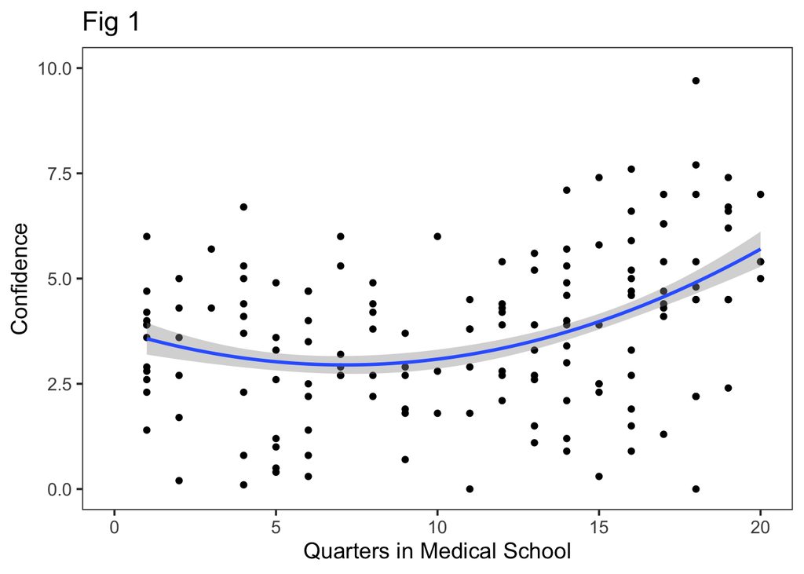

```r
modelplot <- lm(confidence ~ time + I(time^2) + workshop, data = d)


# Set up plot dataframe and model predictions:
d_graph <- expand.grid(time = seq(min(d$time), max(d$time), length=100),
                       workshop = mean(d$workshop, na.rm = T))

d_graph <- ggplotPredict(modelplot, d_graph)

scatterplot <- ggplot() +
  geom_point(data=d, aes(x = time, y = confidence)) +
  geom_smooth(aes(ymin = CILo, ymax = CIHi, x = time, y = Predicted),
              data = d_graph, stat = "identity") +
  scale_x_continuous("Quarters in Medical School") +   # x-axis label
  scale_y_continuous("Confidence") +     # y-axis label

  theme_bw(base_size = 14) +
  labs(x = 'Academic Quarters in Medical School', # indicate a label for the x-axis
       y = 'Confidence',
       title = 'Fig 1') +
  coord_cartesian(ylim = c(0,10), xlim = c(0,20)) + # specify the range of axes
  theme(legend.position = c(.1,.9),                     # positioning legend (play around with values; (0,0) is bottom left, and (1,1) is top right)
        legend.background = element_blank(),               # removing background of legend
        legend.title = element_blank(),
        panel.grid.major = element_blank(),
        panel.grid.minor = element_blank(),
        panel.background = element_blank())
scatterplot
```

## 7. Write a short results section in your Rmarkdown file. Very briefly set up the study and report all statistics that are relevant to the researchers’ hypothesis (report the b’s, F values, p values, and np2). Provide a one-sentence summary or conclusion at the end. (5)

We examined how medical students’ confidence changed over the course of medical school and whether there was a relationship between attending a confidence-boosting workshop and confidence. We hypothesized that students would enter medical school with high confidence, but that confidence would then drop as medical school progressed before eventually rising as students reached the end of medical school. We further hypothesized that attending a confidence-boosting workshop would increase students’ confidence. We found a significant positive quadratic relationship between time spent in medical school and students’ confidence, $b = .02, F(1, 146) = 10.74, p = .001, n_p^2 = 0.07$, when controlling for the linear effect of confidence and whether students attended the workshop. Furthermore, the linear effect of confidence was significant for students who had been in medical school for an average amount of time, $b = .12, F(1, 146) = 22.21, p < .001, n_p^2 = 0.13$, when controlling for the quadratic effect of time in middle school and whether students attended the workshop. Finally, we observed no effect of attending the confidence-boosting workshop, $b = .06, F(1, 146) = 0.04, p < .85, n_p^2 = 0.00$, when controlling for the linear and quadratic effects of time.

# Study 2

## 1. Import and examine your data file (“forecasting.csv”). Include 1 to 2 sentences noting strong/weak relationships between predictors and any odd or unusual stats or distributions. If you notice any observations that must be removed (e.g., observations with impossibly large values), remove them and explain why you did so in one sentence. (3)

```r
d2_raw <- read.csv("/Users/yanzhu/Desktop/sample_code/Design and Analysis of Psychological Experiments/Data/forecasting.csv") %>% janitor::clean_names()

describe(d2_raw)
```

```
##            vars   n   mean    sd median trimmed   mad min max range  skew
## id            1 250 125.50 72.31  125.5  125.50 92.66   1 250   249  0.00
## forecast_1    2 250   4.77  2.60    5.0    4.68  1.48   0  25    25  1.89
## forecast_2    3 249   4.89  2.03    5.0    4.85  1.48   0  10    10  0.20
## forecast_3    4 249   4.87  2.25    5.0    4.86  2.97   0  10    10  0.05
## forecast_4    5 250   4.85  2.35    5.0    4.79  2.97   0  10    10  0.26
## dep_a         6 249   2.41  1.63    2.0    2.16  1.48   1   7     6  1.15
## dep_b         7 250   2.64  1.82    2.0    2.34  1.48   1   7     6  1.06
## dep_c         8 250   2.54  1.80    2.0    2.22  1.48   1   7     6  1.14
## dep_d         9 250   2.46  1.73    2.0    2.14  1.48   1   7     6  1.23
## dep_e        10 249   2.49  1.96    2.0    2.22  1.48 -10   7    17 -0.07
## dep_f        11 250   2.46  1.78    2.0    2.16  1.48   1   7     6  1.15
##            kurtosis   se
## id            -1.21 4.57
## forecast_1    13.28 0.16
## forecast_2    -0.06 0.13
## forecast_3    -0.67 0.14
## forecast_4    -0.58 0.15
## dep_a          0.55 0.10
## dep_b          0.11 0.11
## dep_c          0.32 0.11
## dep_d          0.66 0.11
## dep_e          6.23 0.12
## dep_f          0.27 0.11
```

I noticed that my minimum dep_e score is impossibly low (-10) and my max forecast_1 score is impossibly high (25) values. I will remove these observations.

```r
d2 <- d2_raw %>%
  filter(id != 105)

d2 <- d2 %>%
  filter(id != 85)
```

```r
cor(d2[,c('forecast_1', 'forecast_2', 'forecast_3', 'forecast_4', 'dep_a',
          'dep_b', 'dep_c', 'dep_d', 'dep_e', 'dep_f')])
```

```
##            forecast_1 forecast_2 forecast_3  forecast_4 dep_a      dep_b
## forecast_1  1.0000000         NA         NA  0.48264341    NA -0.3538305
## forecast_2         NA          1         NA          NA    NA         NA
## forecast_3         NA         NA          1          NA    NA         NA
## forecast_4  0.4826434         NA         NA  1.00000000    NA -0.3432252
## dep_a              NA         NA         NA          NA     1         NA
## dep_b      -0.3538305         NA         NA -0.34322518    NA  1.0000000
## dep_c      -0.3997298         NA         NA -0.32435489    NA  0.4396615
## dep_d      -0.3569850         NA         NA -0.02418768    NA  0.2920776
## dep_e              NA         NA         NA          NA    NA         NA
## dep_f      -0.3278839         NA         NA -0.21646737    NA  0.3244661
##                 dep_c       dep_d dep_e      dep_f
## forecast_1 -0.3997298 -0.35698497    NA -0.3278839
## forecast_2         NA          NA    NA         NA
## forecast_3         NA          NA    NA         NA
## forecast_4 -0.3243549 -0.02418768    NA -0.2164674
## dep_a              NA          NA    NA         NA
## dep_b       0.4396615  0.29207762    NA  0.3244661
## dep_c       1.0000000  0.40205009    NA  0.3391124
## dep_d       0.4020501  1.00000000    NA  0.3913281
## dep_e              NA          NA     1         NA
## dep_f       0.3391124  0.39132811    NA  1.0000000
```

Of the correlations I can observe, nothing seems out of the ordinary. Depression scores correlate with each other. However, I have some NAs, which I will have to work around when creating composite scores.

## 2. Create composite (average) scores for depression and affective forecasting. For each of these composite scores, check the reliability of the scale. (3)

```r
d2$dep_m <- varScore(d2, c('dep_a','dep_b','dep_c','dep_d','dep_e', 'dep_f'),
                     Prorate = T, MaxMiss = 0.25)/6
d2$forecast_m <- varScore(d2, c('forecast_1', 'forecast_2', 'forecast_3',
                                'forecast_4'), Prorate = T, MaxMiss = 0.25)/4

psych::alpha(d2[, c('dep_a','dep_b','dep_c','dep_d','dep_e', 'dep_f')])
```

```
##
## Reliability analysis
## Call: psych::alpha(x = d2[, c("dep_a", "dep_b", "dep_c", "dep_d", "dep_e",
##     "dep_f")])
##
##   raw_alpha std.alpha G6(smc) average_r S/N   ase mean  sd median_r
##       0.77      0.76    0.74      0.35 3.2 0.023  2.5 1.2     0.35
##
##     95% confidence boundaries
##          lower alpha upper
## Feldt     0.72  0.77  0.81
## Duhachek  0.72  0.77  0.81
##
##  Reliability if an item is dropped:
##       raw_alpha std.alpha G6(smc) average_r S/N alpha se  var.r med.r
## dep_a      0.75      0.75    0.72      0.38 3.1    0.025 0.0027  0.39
## dep_b      0.72      0.72    0.68      0.34 2.6    0.028 0.0036  0.34
## dep_c      0.72      0.72    0.68      0.34 2.6    0.028 0.0029  0.34
## dep_d      0.73      0.73    0.69      0.35 2.7    0.027 0.0048  0.34
## dep_e      0.72      0.72    0.68      0.34 2.5    0.028 0.0036  0.33
## dep_f      0.74      0.73    0.70      0.36 2.8    0.026 0.0054  0.37
##
##  Item statistics
##         n raw.r std.r r.cor r.drop mean  sd
## dep_a 247  0.59  0.61  0.47   0.41  2.4 1.6
## dep_b 248  0.71  0.70  0.62   0.54  2.6 1.8
## dep_c 248  0.71  0.70  0.62   0.54  2.5 1.8
## dep_d 248  0.68  0.68  0.59   0.51  2.5 1.7
## dep_e 247  0.72  0.71  0.63   0.55  2.6 1.8
## dep_f 248  0.66  0.66  0.56   0.49  2.5 1.8
##
## Non missing response frequency for each item
##          1    2    3    4    5    6    7 miss
## dep_a 0.40 0.23 0.16 0.08 0.08 0.02 0.03    0
## dep_b 0.36 0.23 0.15 0.10 0.06 0.04 0.06    0
## dep_c 0.40 0.21 0.15 0.10 0.04 0.04 0.06    0
## dep_d 0.40 0.23 0.15 0.10 0.04 0.03 0.06    0
## dep_e 0.39 0.20 0.17 0.10 0.05 0.01 0.08    0
## dep_f 0.43 0.22 0.12 0.08 0.08 0.03 0.05    0
```

```r
psych::alpha(d2[, c('forecast_1', 'forecast_2', 'forecast_3', 'forecast_4')])
```

```
## Number of categories should be increased  in order to count frequencies.
```

```
##
## Reliability analysis
## Call: psych::alpha(x = d2[, c("forecast_1", "forecast_2", "forecast_3",
##     "forecast_4")])
##
##   raw_alpha std.alpha G6(smc) average_r S/N   ase mean  sd median_r
##       0.75      0.75     0.7      0.44 3.1 0.025  4.8 1.7     0.43
##
##     95% confidence boundaries
##          lower alpha upper
## Feldt     0.70  0.75   0.8
## Duhachek  0.71  0.75   0.8
##
##  Reliability if an item is dropped:
##            raw_alpha std.alpha G6(smc) average_r S/N alpha se   var.r med.r
## forecast_1      0.71      0.71    0.62      0.45 2.4    0.032 0.00089  0.46
## forecast_2      0.71      0.71    0.63      0.45 2.5    0.032 0.00192  0.47
## forecast_3      0.70      0.70    0.62      0.44 2.4    0.032 0.00249  0.46
## forecast_4      0.66      0.67    0.57      0.40 2.0    0.037 0.00019  0.40
##
##  Item statistics
##              n raw.r std.r r.cor r.drop mean  sd
## forecast_1 248  0.75  0.75  0.61   0.53  4.7 2.3
## forecast_2 247  0.73  0.74  0.60   0.53  4.9 2.0
## forecast_3 247  0.76  0.75  0.62   0.54  4.9 2.2
## forecast_4 248  0.80  0.79  0.70   0.61  4.9 2.3
```

- Cronbach’s Alpha for the depression scale is 0.77
- Cronbach’s Alpha for the affective forecasting scale is 0.75

## 3. Fit a model predicting depression from active forecasting. Provide a 1- to 2-sentence summary of your results, include the b estimate of the focal predictor, F values, p values, and np2. (2)

```r
m1 <- lm(dep_m ~ forecast_m, data = d2)
summary(m1)
```

```
##
## Call:
## lm(formula = dep_m ~ forecast_m, data = d2)
##
## Residuals:
##     Min      1Q  Median      3Q     Max
## -2.2204 -0.7896 -0.1102  0.6632  2.8674
##
## Coefficients:
##             Estimate Std. Error t value Pr(>|t|)
## (Intercept)  4.15047    0.20242  20.504  < 2e-16 ***
## forecast_m  -0.33930    0.03951  -8.588 1.03e-15 ***
## ---
## Signif. codes:  0 '***' 0.001 '**' 0.01 '*' 0.05 '.' 0.1 ' ' 1
##
## Residual standard error: 1.047 on 246 degrees of freedom
## Multiple R-squared:  0.2307, Adjusted R-squared:  0.2275
## F-statistic: 73.75 on 1 and 246 DF,  p-value: 1.028e-15
```

```r
car::Anova(m1, type = 3)
```

```
## Anova Table (Type III tests)
##
## Response: dep_m
##             Sum Sq  Df F value    Pr(>F)
## (Intercept) 461.22   1 420.416 < 2.2e-16 ***
## forecast_m   80.91   1  73.752 1.028e-15 ***
## Residuals   269.88 246
## ---
## Signif. codes:  0 '***' 0.001 '**' 0.01 '*' 0.05 '.' 0.1 ' ' 1
```

```r
car::Anova(m1, type = 3) %>% eta_squared()
```

```
## For one-way between subjects designs, partial eta squared is equivalent
##   to eta squared. Returning eta squared.
```

```
## # Effect Size for ANOVA
##
## Parameter  | Eta2 |       95% CI
## --------------------------------
## forecast_m | 0.23 | [0.16, 1.00]
##
## - One-sided CIs: upper bound fixed at [1.00].
```

We observe that an individual’s affective forecasting ability negatively predicts depression, such that for every 1 unit increase in affective forecasting a person’s depression score decreases by 0.34 units, $b_1 = -0.34, F(1, 246) = 73.75, p < .001, n_p^2 = 0.23$.

## 4. Create a scatterplot in which you plot a participant’s average depression score on the y axis and their average affective forecasting score on the x axis. Does this relationship appear linear? (2)

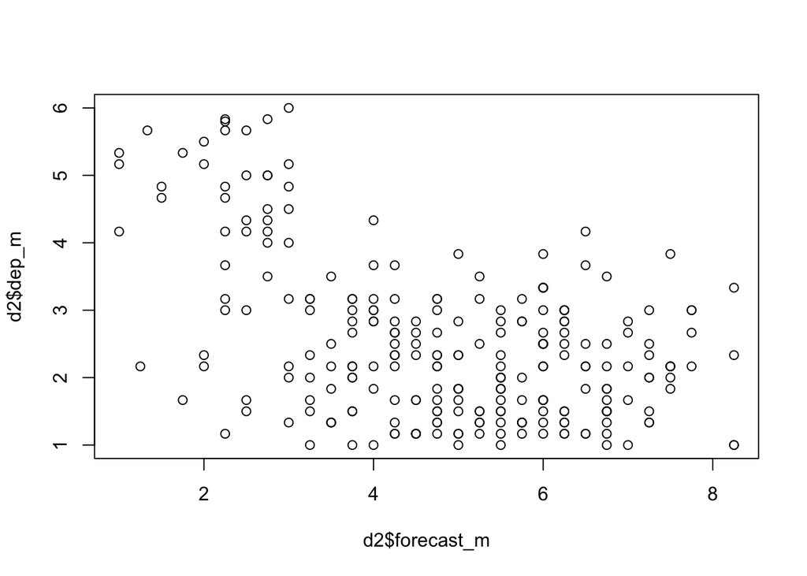

```r
plot(d2$forecast_m, d2$dep_m)
```

The relationship between the composite affective forecasting scores and the composite depression scores appears to have a slight curve. Based on this visual inspection, it is probable that the linearity assumption has been violated.

## 5. Determine if your data include any observations that should be removed because they are regression outliers or have high influence on the model. (2)

```r
x_hats <- modelCaseAnalysis(m1, Type = "HATVALUES")
```

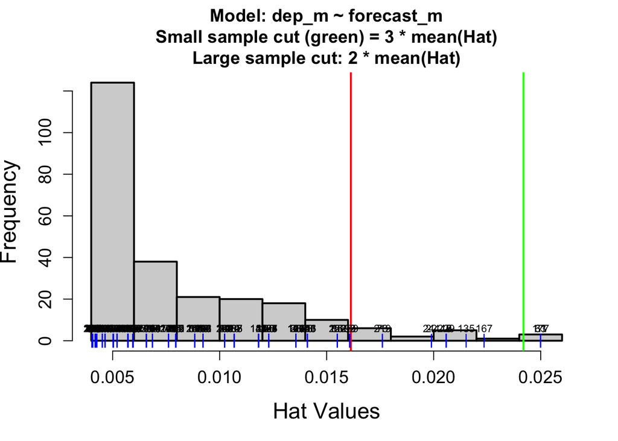

```r
x_resids <- modelCaseAnalysis(m1, Type = "RESIDUALS")
```

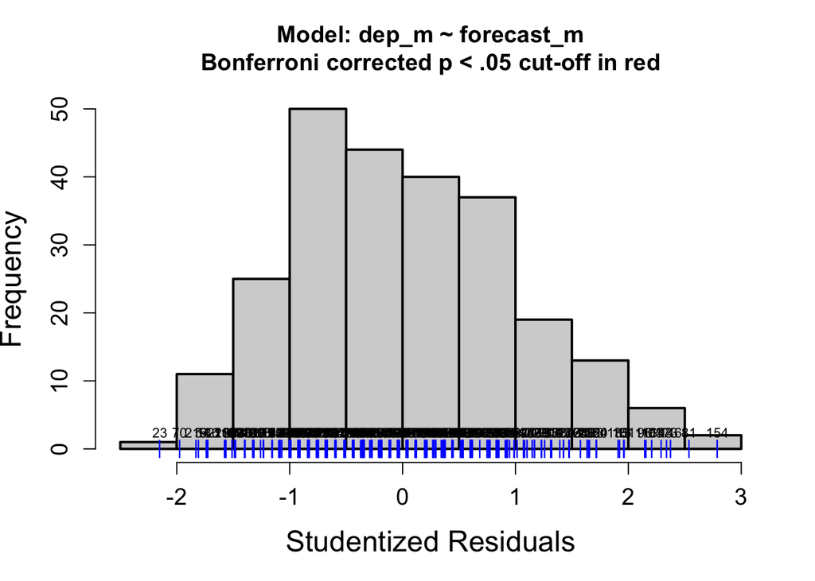

There are no regression outliers in these data.

```r
x_cooks <- modelCaseAnalysis(m1, Type = "COOKSD")
```

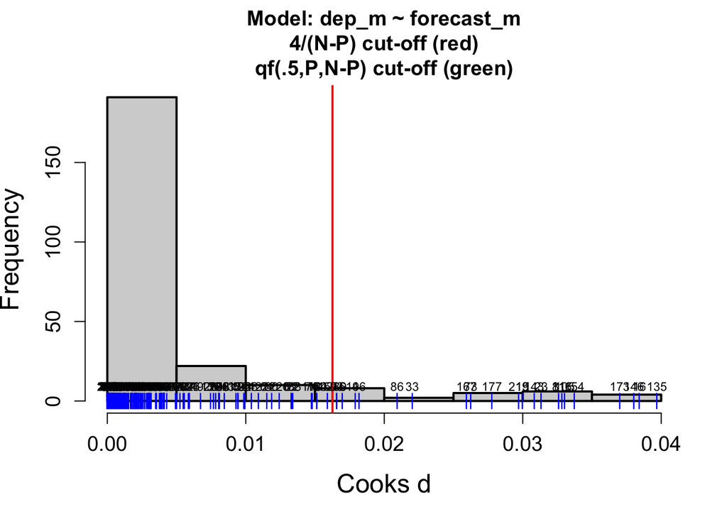

There are several points beyond the cutoff indicating high influence. However, given that there is no gap in our histogram bins and the large number of scores beyond that cutoff, I identify no points that I would consider removing due to high influence.

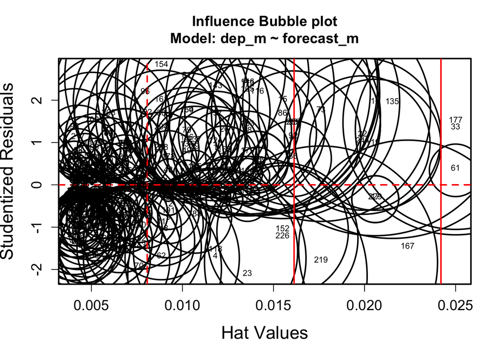

```r
x_infs <- modelCaseAnalysis(m1, Type = "INFLUENCEPLOT")
```

## 6. Determine if the model assumptions of normality, constant variance, and linearity have been violated. Write 2 to 3 sentences describing what you find. (2)

NOTE: Rmarkdown does not include the images for the modelAssumptions package upon knitting. To see the answer key images, please download the R Markdown file.

```r
modelAssumptions(m1, Type = "NORMAL")
```

```
## Descriptive Statistics for Studentized Residuals
```

```
##    vars   n mean   sd median trimmed  mad   min  max range skew kurtosis   se
## X1    1 248    0 1.01  -0.11   -0.04 1.07 -2.15 2.79  4.94 0.35    -0.43 0.06
```

```r
modelAssumptions(m1, Type = "CONSTANT")
```

```
##
## Suggested power transformation:  0.05409199
##
##
## Non-constant Variance Score Test
## Variance formula: ~ fitted.values
## Chisquare = 26.37514, Df = 1, p = 2.8114e-07
```

```r
modelAssumptions(m1, Type = "LINEAR")
```

## 7. Regardless of your answers to questions 5 and 6, use the same model from question 3 and determine a recommended transformation that you could apply to these data to ensure that your model better fits the model assumptions. (2)

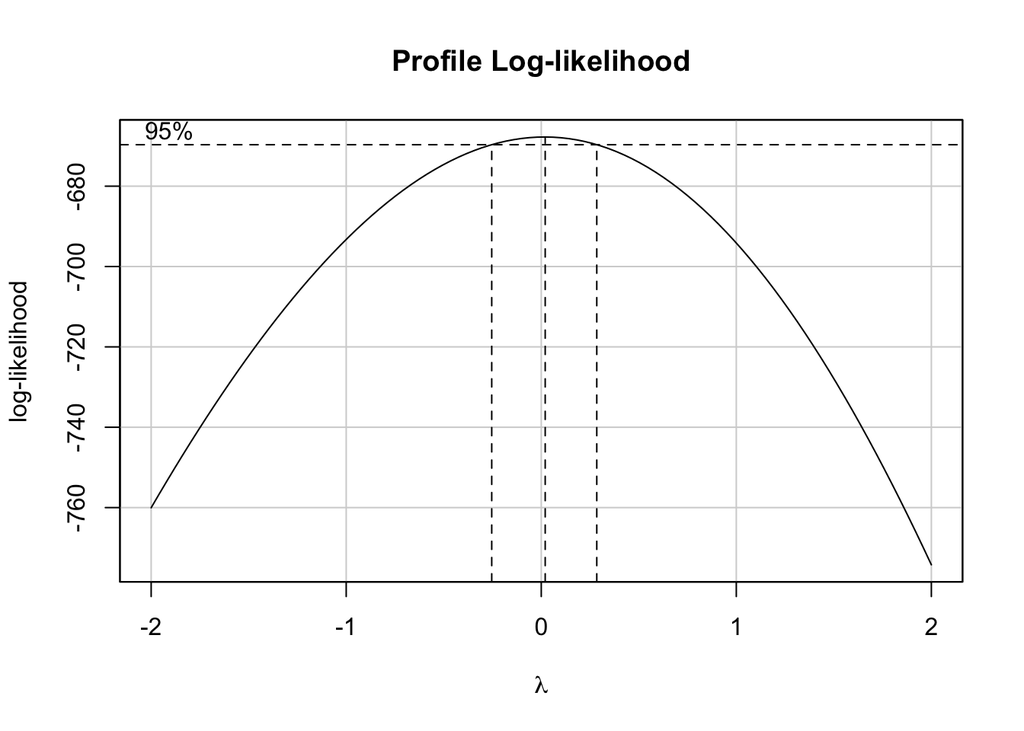

```
## [1] "Best Lambda= 0.02"
## [1] "Chi-square (df=1)= 53.9"
## [1] "p-value= 0"
```

```r
modelBoxCox(m1)
```

The modelBoxCox code recommends a power transformation of lambda = 0.02, however I do not know how to interpret that transformation. Given the shape of the curve from our component residual / partial residual plot, I am would use a log transformation to move x or y down the ladder.

## 8. Based on your answer to question 7 apply a transformation to your data. Be sure to pick a transformation that you can interpret. (2)

```r
d2$forecast_m_trans <- log2(d2$forecast_m)
```

## 9. Re-fit a model predicting depression scores from the affective forecasting scores, using the transformed data. Determine if your transformed data corrected the violations of our model assumptions. (2)

```r
m2 <- lm(dep_m ~ forecast_m_trans, data = d2)
summary(m2)
```

```
##
## Call:
## lm(formula = dep_m ~ forecast_m_trans, data = d2)
##
## Residuals:
##      Min       1Q   Median       3Q      Max
## -2.39158 -0.76828 -0.04156  0.65930  2.87973
##
## Coefficients:
##                  Estimate Std. Error t value Pr(>|t|)
## (Intercept)        4.7928     0.2362   20.29   <2e-16 ***
## forecast_m_trans  -1.0553     0.1051  -10.04   <2e-16 ***
## ---
## Signif. codes:  0 '***' 0.001 '**' 0.01 '*' 0.05 '.' 0.1 ' ' 1
##
## Residual standard error: 1.006 on 246 degrees of freedom
## Multiple R-squared:  0.2908, Adjusted R-squared:  0.2879
## F-statistic: 100.9 on 1 and 246 DF,  p-value: < 2.2e-16
```

```r
car::Anova(m2, type = 3)
```

```
## Anova Table (Type III tests)
##
## Response: dep_m
##                  Sum Sq  Df F value    Pr(>F)
## (Intercept)      416.31   1  411.66 < 2.2e-16 ***
## forecast_m_trans 102.02   1  100.88 < 2.2e-16 ***
## Residuals        248.77 246
## ---
## Signif. codes:  0 '***' 0.001 '**' 0.01 '*' 0.05 '.' 0.1 ' ' 1
```

```r
car::Anova(m2, type = 3) %>% eta_squared()
```

```
## For one-way between subjects designs, partial eta squared is equivalent
##   to eta squared. Returning eta squared.
```

```
## # Effect Size for ANOVA
##
## Parameter        | Eta2 |       95% CI
## --------------------------------------
## forecast_m_trans | 0.29 | [0.22, 1.00]
##
## - One-sided CIs: upper bound fixed at [1.00].
```

```r
modelAssumptions(m2, Type = "NORMAL")
```

```
## Descriptive Statistics for Studentized Residuals
```

```
##    vars   n mean   sd median trimmed  mad   min  max range skew kurtosis   se
## X1    1 248    0 1.01  -0.04   -0.03 1.06 -2.42 2.92  5.34 0.25    -0.25 0.06
```

The log2 transformation slightly improved the normality of the residuals in the model.

```r
modelAssumptions(m2, Type = "CONSTANT")
```

```
##
## Suggested power transformation:  0.1064367
##
##
## Non-constant Variance Score Test
## Variance formula: ~ fitted.values
## Chisquare = 27.62815, Df = 1, p = 1.4702e-07
```

```r
modelAssumptions(m2, Type = "LINEAR")
```

## 10. Provide a 1- to 2-sentence summary of the model you fit in question 9. Including the b estimate of the focal predictor, F values, p values, and np2. Make sure that your summary includes a conceptual interpretation of your b1 estimate, which could be understood by someone who is not an expert in statistics. (3)

# Study 3

```r
d3 <- read.csv("/Users/yanzhu/Desktop/sample_code/Design and Analysis of Psychological Experiments/Data/utility_value.csv") %>% janitor::clean_names()

describe(d3)
```

```
##              vars   n mean   sd median trimmed  mad  min max range  skew
## intervention    1 500 0.47 0.50   0.00    0.46 0.00 0.00   1  1.00  0.12
## stem            2 500 0.49 0.50   0.00    0.49 0.00 0.00   1  1.00  0.03
## exp             3 500 2.52 1.70   3.00    2.52 1.48 0.00   5  5.00 -0.04
## gpa             4 500 2.52 0.71   2.44    2.51 0.56 0.03   4  3.97  0.09
##              kurtosis   se
## intervention    -1.99 0.02
## stem            -2.00 0.02
## exp             -1.26 0.08
## gpa              0.21 0.03
```

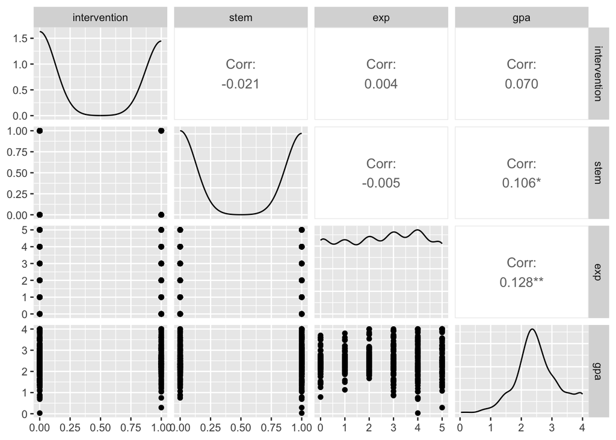

```r
GGally::ggpairs(d3)
```

```r
table(d3$stem)
```

```
##
##   0   1
## 254 246
```

```r
table(d3$intervention)
```

```
##
##   0   1
## 265 235
```

All values from these data are within the anticipated range. I observe a positive correlation between stem course and GPA as well as between experience and GPA. I also note that we have unequal cell sizes for both the stem and intervention predictors.

## 2. Fit a model to test if being in a STEM (versus) non-STEM course interacts with whether students took part in the utility value intervention to predict students’ GPA at graduation. Be sure to center any variables that should be centered for easier interpretation of your results. (3)

```r
d3$stem_c <- dplyr::recode(d3$stem,
                           "0" = -0.5,
                           "1" = 0.5)

d3$intervention_c <- dplyr::recode(d3$intervention,
                           "0" = -0.5,
                           "1" = 0.5)

mod1 <- lm(gpa ~ stem_c * intervention_c, data = d3)
summary(mod1)
```

```
##
## Call:
## lm(formula = gpa ~ stem_c * intervention_c, data = d3)
##
## Residuals:
##      Min       1Q   Median       3Q      Max
## -2.46549 -0.39657 -0.07992  0.38714  1.54076
##
## Coefficients:
##                       Estimate Std. Error t value Pr(>|t|)
## (Intercept)            2.52968    0.03141  80.525   <2e-16 ***
## stem_c                 0.16020    0.06283   2.550   0.0111 *
## intervention_c         0.10463    0.06283   1.665   0.0965 .
## stem_c:intervention_c  0.24791    0.12566   1.973   0.0491 *
## ---
## Signif. codes:  0 '***' 0.001 '**' 0.01 '*' 0.05 '.' 0.1 ' ' 1
##
## Residual standard error: 0.7009 on 496 degrees of freedom
## Multiple R-squared:  0.02422,    Adjusted R-squared:  0.01831
## F-statistic: 4.103 on 3 and 496 DF,  p-value: 0.006819
```

```r
car::Anova(mod1, type = 3)
```

```
## Anova Table (Type III tests)
##
## Response: gpa
##                       Sum Sq  Df   F value  Pr(>F)
## (Intercept)           3185.6   1 6484.2219 < 2e-16 ***
## stem_c                   3.2   1    6.5011 0.01108 *
## intervention_c           1.4   1    2.7731 0.09649 .
## stem_c:intervention_c    1.9   1    3.8921 0.04907 *
## Residuals              243.7 496
## ---
## Signif. codes:  0 '***' 0.001 '**' 0.01 '*' 0.05 '.' 0.1 ' ' 1
```

```r
car::Anova(mod1, type = 3) %>% eta_squared()
```

```
## Type 3 ANOVAs only give sensible and informative results when covariates
##   are mean-centered and factors are coded with orthogonal contrasts (such
##   as those produced by `contr.sum`, `contr.poly`, or `contr.helmert`, but
##   *not* by the default `contr.treatment`).
```

```
## # Effect Size for ANOVA (Type III)
##
## Parameter             | Eta2 (partial) |       95% CI
## -----------------------------------------------------
## stem_c                |           0.01 | [0.00, 1.00]
## intervention_c        |       5.56e-03 | [0.00, 1.00]
## stem_c:intervention_c |       7.79e-03 | [0.00, 1.00]
##
## - One-sided CIs: upper bound fixed at [1.00].
```

## 3. Provide a full interpretation of each of the parameter estimates from the model you fit in question 2. A full interpretation of a parameter includes a practical explanation for the b value and states which other effects (if any) were controlled for when calculating that b value. (4)

- $b_0$ = 2.53, this is the predicted GPA for a student who is hypothetically half way between having taken and not having taken the utility value intervention and who is hypothetically half way between being in a stem and non-stem course.
- $b_1$ = 0.16, being in a STEM course (versus a non-STEM course) leads to a 0.16 unit increase in student GPA for a student who is hypothetically half way between having taken and not having taken the utility value intervention, when statistically controlling for the effects of the utility value intervention and the interaction between being in a STEM course and taking the utility value intervention.
- $b_2$ = 0.10, taking part in the utility value intervention leads to a 0.10 unit increase in GPA for a student who is hypothetically half way between being in a STEM and non-STEM course, when statistically controlling for the effects of being in a STEM course and the interaction between being in a STEM course and taking the utility value intervention.
- $b_3$ = 0.25, the effect of the utility value intervention is 0.25 units higher in STEM classes than in non-STEM classes, when statistically controlling for the effects of taking the utility value intervention and being in a STEM course.

## 4. What is the simple effect of the utility value intervention for participants in a non-STEM course. (2)

Recode method:

```r
mod1_b <- lm(gpa ~ stem * intervention, data = d3)
summary(mod1_b)
```

```
##
## Call:
## lm(formula = gpa ~ stem * intervention, data = d3)
##
## Residuals:
##      Min       1Q   Median       3Q      Max
## -2.46549 -0.39657 -0.07992  0.38714  1.54076
##
## Coefficients:
##                   Estimate Std. Error t value Pr(>|t|)
## (Intercept)        2.45924    0.06101  40.311   <2e-16 ***
## stem               0.03625    0.08611   0.421   0.6740
## intervention      -0.01932    0.08803  -0.220   0.8263
## stem:intervention  0.24791    0.12566   1.973   0.0491 *
## ---
## Signif. codes:  0 '***' 0.001 '**' 0.01 '*' 0.05 '.' 0.1 ' ' 1
##
## Residual standard error: 0.7009 on 496 degrees of freedom
## Multiple R-squared:  0.02422,    Adjusted R-squared:  0.01831
## F-statistic: 4.103 on 3 and 496 DF,  p-value: 0.006819
```

The simple effect of intervention is -0.02

By hand:

- 2.53 + 0.16 * stem_c + 0.10 * intervention_c + 0.25 * stem_c * intervention_c
- 2.53 + 0.16 * (-0.5) + 0.10 * intervention_c + 0.25 * (-0.5) * intervention_c
- 2.45 + 0.10 * intervention - .125 * intervention
- 2.45 - 0.025 * intervention (note slight difference due to rounding)

## 5. What is the predicted GPA for each of the following groups:

### a. Students who took part in the utility value intervention and are in a non-STEM course? (.5)

- 2.53 + 0.16 * -0.5 + 0.10 * 0.5 + 0.25 * -0.5 * 0.5 = 2.44

### b. Students who took part in the utility value intervention and are in a STEM course? (.5)

- 2.53 + 0.16 * 0.5 + 0.10 * 0.5 + 0.25 * 0.5 * 0.5 = 2.72

### c. Students who did not take part in the utility value intervention and are in a non-STEM course? (.5)

- 2.53 + 0.16 * -0.5 + 0.10 * -0.5 + 0.25 * -0.5 * -0.5 = 2.46

### d. Students who did not take part in the utility value intervention and are in a STEM course? (.5)

- 2.53 + 0.16 * 0.5 + 0.10 * -0.5 + 0.25 * 0.5 * -0.5 = 2.50

## 6. Fit a model to test if being in a STEM (versus) non-STEM course interacts with experience to predict students’ GPA at graduation. Be sure to center any variables that should be centered for easier interpretation of your results. (3)

```r
d3$exp_c <- d3$exp - mean(d3$exp, na.rm = T)

mod2 <- lm(gpa ~ stem_c * exp_c, data = d3)
summary(mod2)
```

```
##
## Call:
## lm(formula = gpa ~ stem_c * exp_c, data = d3)
##
## Residuals:
##      Min       1Q   Median       3Q      Max
## -2.73411 -0.38004 -0.04395  0.40463  1.55796
##
## Coefficients:
##              Estimate Std. Error t value Pr(>|t|)
## (Intercept)   2.52567    0.03100  81.482  < 2e-16 ***
## stem_c        0.15137    0.06199   2.442  0.01497 *
## exp_c         0.05324    0.01827   2.914  0.00373 **
## stem_c:exp_c  0.11287    0.03654   3.089  0.00212 **
## ---
## Signif. codes:  0 '***' 0.001 '**' 0.01 '*' 0.05 '.' 0.1 ' ' 1
##
## Residual standard error: 0.693 on 496 degrees of freedom
## Multiple R-squared:  0.04612,    Adjusted R-squared:  0.04035
## F-statistic: 7.994 on 3 and 496 DF,  p-value: 3.264e-05
```

```r
car::Anova(mod2, type = 3)
```

```
## Anova Table (Type III tests)
##
## Response: gpa
##              Sum Sq  Df   F value    Pr(>F)
## (Intercept)  3188.6   1 6639.3591 < 2.2e-16 ***
## stem_c          2.9   1    5.9617  0.014968 *
## exp_c           4.1   1    8.4914  0.003729 **
## stem_c:exp_c    4.6   1    9.5425  0.002120 **
## Residuals     238.2 496
## ---
## Signif. codes:  0 '***' 0.001 '**' 0.01 '*' 0.05 '.' 0.1 ' ' 1
```

```r
car::Anova(mod2, type = 3) %>% eta_squared()
```

```
## Type 3 ANOVAs only give sensible and informative results when covariates
##   are mean-centered and factors are coded with orthogonal contrasts (such
##   as those produced by `contr.sum`, `contr.poly`, or `contr.helmert`, but
##   *not* by the default `contr.treatment`).
```

```
## # Effect Size for ANOVA (Type III)
##
## Parameter    | Eta2 (partial) |       95% CI
## --------------------------------------------
## stem_c       |           0.01 | [0.00, 1.00]
## exp_c        |           0.02 | [0.00, 1.00]
## stem_c:exp_c |           0.02 | [0.00, 1.00]
##
## - One-sided CIs: upper bound fixed at [1.00].
```

## 7. Refit the model from question 6 using uncentered predictors. Make a publication quality graph depicting the interaction from this recentered model. Experience should be graphed on the x-axis. Include a dashed line, representing participants who are hypothetically half way between being in a STEM versus non-STEM course. For full points, your graph must include a regression line (or lines), raw data points, confidence intervals representing the standard error of the point estimate, a title, clear labels on the x and y axis, and have a blank white background. (6)

```r
m_graph <- lm(gpa ~ stem * exp, data = d3)
summary(m_graph)
```

```
##
## Call:
## lm(formula = gpa ~ stem * exp, data = d3)
##
## Residuals:
##      Min       1Q   Median       3Q      Max
## -2.73411 -0.38004 -0.04395  0.40463  1.55796
##
## Coefficients:
##              Estimate Std. Error t value Pr(>|t|)
## (Intercept)  2.458033   0.078451  31.332  < 2e-16 ***
## stem        -0.132626   0.110879  -1.196  0.23222
## exp         -0.003199   0.025874  -0.124  0.90166
## stem:exp     0.112874   0.036540   3.089  0.00212 **
## ---
## Signif. codes:  0 '***' 0.001 '**' 0.01 '*' 0.05 '.' 0.1 ' ' 1
##
## Residual standard error: 0.693 on 496 degrees of freedom
## Multiple R-squared:  0.04612,    Adjusted R-squared:  0.04035
## F-statistic: 7.994 on 3 and 496 DF,  p-value: 3.264e-05
```

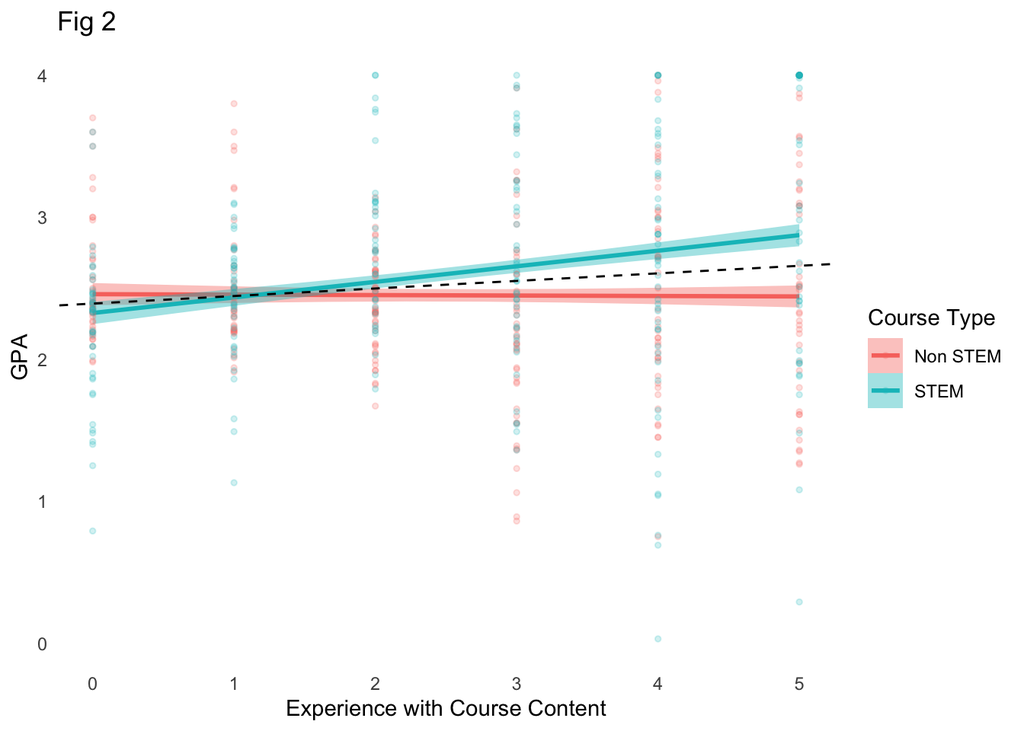

```r
d_graph <- expand.grid(exp = seq(min(d3$exp), max(d3$exp), length = 10),
                       stem = c(0, 1))

d_graph <- ggplotPredict(m_graph, d_graph)

d_graph$stem_str <- dplyr::recode(d_graph$stem,
                                       "0" = "Non STEM",
                                       "1" = "STEM")

d3$stem_str <- dplyr::recode(d3$stem,
                             "0" = "Non STEM",
                             "1" = "STEM")

ggplot(d3, aes(x = exp, y = gpa, color = stem_str, fill = stem_str)) +
  geom_smooth(data = d_graph, stat = "identity",
              aes(y = Predicted, ymin = CILo, ymax = CIHi))+
  geom_point(aes(), alpha = .2, size=1) +
  labs(x = "Experience with Course Content", y = "GPA", title = "Fig 2",
       color = "Course Type", fill = "Course Type") +
  theme_minimal() +
  theme(
    panel.grid.major = element_blank(), # remove gridlines
    panel.grid.minor = element_blank(), # remove gridlines
    legend.background = element_blank() # removing background of legend
  ) +
  geom_abline(intercept = 2.39172, # found from 2.458033 + -0.132626 * 0.5
              slope = 0.05324, # b2 from m_graph
              linetype = "dashed")
```

## 8. Identify where on the graph you observe each of the parameter estimates from the model you fit in question 6. (4)

- $b_0$ is the y-intercept of the red line, or when experience with course content = 0 for non-STEM courses
- $b_1$ is the difference between the red and blue lines for participants who have an experience score of 0
- $b_2$ is the slope of a the red line (when STEM = 0)
- $b_3$ is the magnitude by which the difference between the blue and red line increases as experience increases.

## 9. Provide a 2- to 3-sentence summary of the results from the model you fit in question 6. For full points, explain what variables you controlled for and why; include the b’s, F values, p values, and np2; and include a conceptual interpretation of your b3 estimate, which could be understood by someone who is not an expert. (3)

We examined whether the effect of experience on GPA [or: the relationship between experience and GPA] depends on the type of course that students are in (STEM vs. non-STEM) to predict students’ GPA.We regressed students’ GPA on a measure of their experience, the course type (STEM versus non-STEM), and the interaction of the two. We found that for every 1 unit increase in experience with course content, the difference in GPA between students in STEM courses and students in non-STEM courses increased by 0.11 points, $b3 = 0.11, F(1, 496) = 9.54, n_p^2 = 0.02$.

## How long did this assingment take?

Congratulations on completing 610!